# FIST Cards Report

Sofija Kostic

## Project aim

The `fistcards` package provides an online version of the FIST card task. It defines the stimulus deck, generates valid Phase 1 and Phase 2 trials, scores responses, and runs a Shiny app for collecting participant data.

The goal of the project is to create a reusable research tool for measuring cognitive flexibility in young children aged 2 to 7. In the task, children compare cards that vary on three dimensions: colour, animal, and number. The online version makes it possible to present the task interactively, record structured responses, and keep the task logic in testable R functions.

This report describes the final project version. It explains the structure of the cards, the two task phases, the Shiny app, and the tests used to check the main logic.

## Package structure

The project is organized as an R package so that the task logic, app, images, tests, and documentation can be installed and reused together.

- `R/cards.R` creates the card deck, image paths, and card lookup helper.
- `R/card_logic.R` compares cards and identifies correct choices.
- `R/trials.R` generates valid trials for both task phases.
- `R/run_fist_game.R` launches the packaged Shiny app.
- `inst/app/app.R` contains the Shiny interface and server logic.
- `inst/app/www/cards` stores the card images used by the app.
- `tests/testthat` contains automated tests for logic, assets, and app flow.

## Card structure

Each card is described by its colour, animal, number, and image path. The full deck has 27 cards: three colours, three animals, and three numbers.

```r
library(fistcards)

cards <- fist_cards()
nrow(cards)
```

```
#> [1] 27
```

```r
head(cards)
```

```
#>               id colour animal number                    image
#> 1    blue_frog_1   blue   frog      1    cards/blue_frog_1.png
#> 2     red_frog_1    red   frog      1     cards/red_frog_1.png
#> 3  yellow_frog_1 yellow   frog      1  cards/yellow_frog_1.png
#> 4   blue_snail_1   blue  snail      1   cards/blue_snail_1.png
#> 5    red_snail_1    red  snail      1    cards/red_snail_1.png
#> 6 yellow_snail_1 yellow  snail      1 cards/yellow_snail_1.png
```

The card images are stored inside the package so the app can find them on any computer after installation. The examples below show three cards from the same animal category.

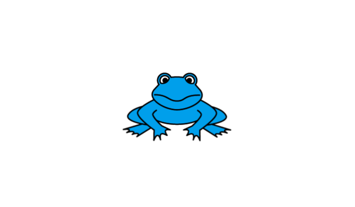

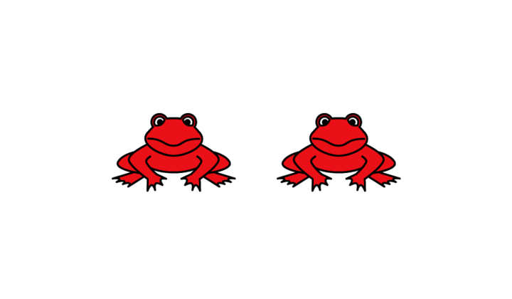

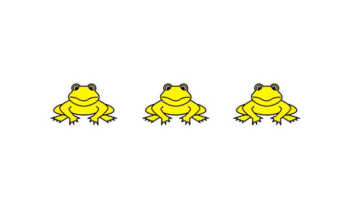

## Phase 1

In Phase 1, children see one target card and two possible answer cards. The correct answer is the card that shares exactly one dimension with the target card. The distractor card shares no dimensions with the target card. The two answer options are also kept fully distinct from each other, so they do not share colour, animal, or number.

Phase 1 rule:

- correct choice: shares exactly one feature with the target
- distractor: shares zero features with the target
- answer options: share zero features with each other

```r
phase1_trials <- generate_phase1_trials(n = 5, seed = 1)
phase1_trials
```

```
#>      phase    trial_id      target_id     choice1_id    choice2_id
#> 1017     1 phase1_1017   blue_snail_3 yellow_snail_1    red_frog_2
#> 679      1 phase1_0679 yellow_snail_2   blue_snail_1 red_chicken_3
#> 129      1 phase1_0129  yellow_frog_1    blue_frog_3   red_snail_2
#> 930      1 phase1_0930     red_frog_3 yellow_snail_1   blue_frog_2
#> 471      1 phase1_0471    blue_frog_2  yellow_frog_3 red_chicken_1
#>      correct_choice
#> 1017              1
#> 679               1
#> 129               1
#> 930               2
#> 471               1
```

The scoring helper returns the position of the correct choice.

```r
target <- list(colour = "blue", animal = "frog", number = 1)
choice1 <- list(colour = "yellow", animal = "frog", number = 3)
choice2 <- list(colour = "red", animal = "snail", number = 2)

correct_phase1_choice(choice1, choice2, target)
```

```
#> [1] 1
```

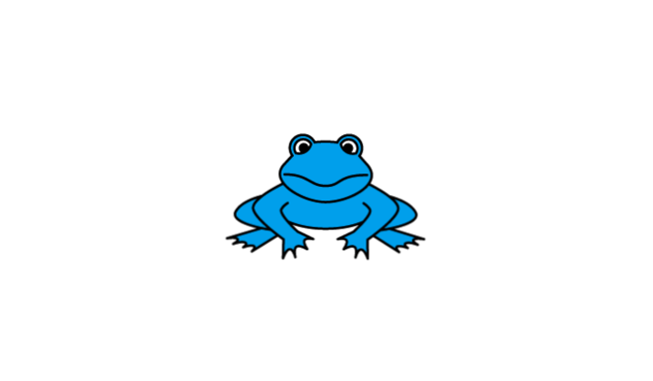

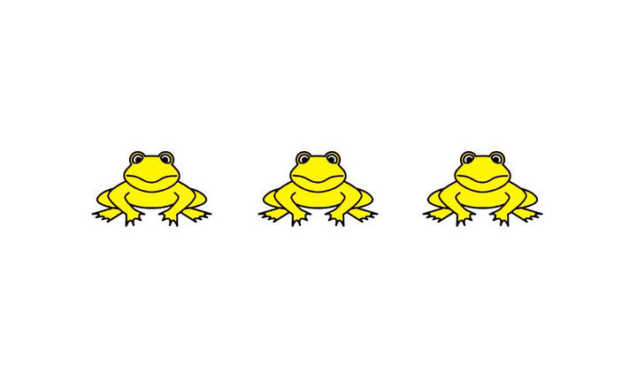

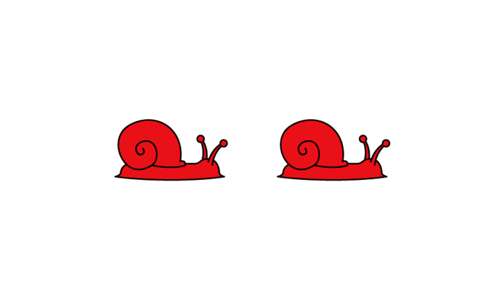

## Phase 2

In Phase 2, children see three cards and choose the special card. A valid special card shares exactly one dimension with one card and exactly one different dimension with the other card. The two non-special cards do not share any dimensions with each other.

Phase 2 rule:

- special card: shares exactly one feature with each other card
- shared dimensions: must be different
- non-special cards: share zero features with each other

```r
phase2_trials <- generate_phase2_trials(n = 5, seed = 1)
phase2_trials
```

```
#>     phase    trial_id         card1_id       card2_id       card3_id
#> 129     2 phase2_0129       red_frog_1 blue_chicken_2    blue_frog_3
#> 509     2 phase2_0509      blue_frog_2 yellow_snail_2     red_frog_3
#> 471     2 phase2_0471 yellow_chicken_1     red_frog_2  yellow_frog_3
#> 299     2 phase2_0299      red_snail_1  yellow_frog_2   blue_snail_2
#> 270     2 phase2_0270     blue_snail_1  yellow_frog_3 blue_chicken_3
#>     correct_choice
#> 129              3
#> 509              1
#> 471              3
#> 299              3
#> 270              3
```

The scoring helper returns which of the three cards is the special card.

```r
special_card <- list(colour = "red", animal = "frog", number = 1)
animal_match <- list(colour = "blue", animal = "frog", number = 2)
colour_match <- list(colour = "red", animal = "snail", number = 3)

correct_phase2_choice(special_card, animal_match, colour_match)
```

```
#> [1] 1
```

[figure not shown]

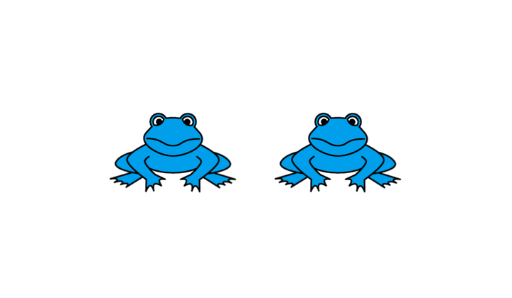

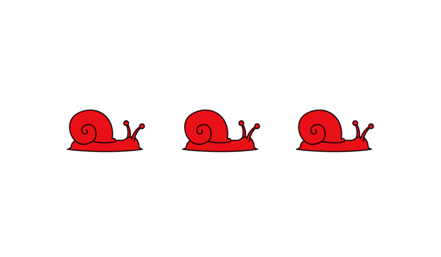

## Trial generation

Trials are not manually entered one by one. The package generates card combinations from the full deck and keeps only those that satisfy the task rules.

For Phase 1, the generator loops through possible target cards, matching cards, and distractors. It uses `correct_phase1_choice()` to keep trials where exactly one choice shares one feature with the target and the other choice shares none.

For Phase 2, similarly, the generator checks three-card combinations with `correct_phase2_choice()`. A combination is kept only when exactly one card fits the special-card rule: it shares exactly one feature with each of the other two cards, those shared features are different, and the other two cards share no features with each other.

This rule-based approach helps prevent invalid trials and keeps the Shiny app from relying on hand-coded answers.

## Scenario

The purpose of this scenario is to show how the `fistcards` Shiny app can be used to run one FIST card task session with a child participant and produce a downloadable data file for later analysis.

The representative user is a developmental psychology researcher who wants to collect structured responses from a young child. In this example, the researcher is working with a 5-year-old participant in a quiet testing room. The researcher prepares the session, explains the task, and saves the data. The child participant interacts only with the card-choice screens by selecting the card they think is correct.

The scenario assumes that the researcher has a computer with R, the required R packages, and a supported web browser installed. The `fistcards` package can be installed from GitHub or loaded from a local copy of the project. The computer also needs access to the packaged card images in `inst/app/www/cards`, which are included when the package is installed. No extra files need to be entered by the participant during the task.

The package dependencies are:

- `glue`: used for building text values in the package
- `shiny`: used to run the interactive web app
- `pkgload`: used by the vignette when loading a local package copy
- `knitr` and `rmarkdown`: used to build this vignette/report
- `shinytest2`: used for browser-based Shiny app tests
- `testthat`: used for automated unit tests

The example installation commands below also use `remotes` for installing from GitHub and `devtools` for loading or testing a local copy of the package.

The interaction proceeds as follows:

1. The researcher opens R and launches the app with `run_fist_game()`.
2. The software opens the Shiny interface in a browser.
3. The researcher enters an anonymous participant ID and chooses the number of Phase 1 and Phase 2 trials.
4. The software generates valid trials from the packaged card deck.
5. The researcher starts the task and gives the child the instruction screen.
6. In Phase 1, the child sees a target card and two possible answer cards. The child clicks the answer card that goes with the target card.
7. After each click, the software records the chosen card, whether the response was correct, and the reaction time.
8. In Phase 2, the child sees three cards and clicks the special card that matches the other two cards in different ways.
9. When all trials are complete, the software shows a thank-you screen.
10. The researcher continues to the results screen, checks the score summary, and downloads the response data as a CSV file.

The main user input options are the participant ID, the number of trials in each phase, and the card choices made during the task. The main outputs are the on-screen score summary and the downloadable CSV file containing trial-level responses.

## Flowchart

The flowchart below separates the user steps from the software functions.

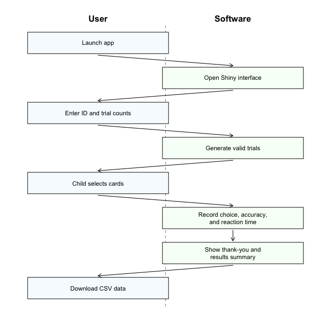

## Shiny app

The interactive version can be launched from R:

```r
remotes::install_github(
  "Programming-The-Next-Step-2026/fist-cards",
  subdir = "fistcards"
)

library(fistcards)
run_fist_game()
```

When working with a downloaded copy of the project, the package can be loaded directly from the local files:

```r
devtools::load_all("fistcards")
run_fist_game()
```

In the app, the researcher first enters the participant ID and chooses how many trials to run in each phase. The participant then moves through the instruction screens, completes the card choices, sees a thank-you screen, and can then view the results summary and download the response data.

The workflow separates the researcher and participant roles. The researcher configures the session and downloads the data, while the child participant only interacts with the card-choice screens.

The app currently includes:

- a participant ID field
- configurable trial counts for Phase 1 and Phase 2
- introductory example screens before each phase
- clickable card choices
- response recording with accuracy and reaction time
- a thank-you screen after the final trial
- a separate results screen with a summary and CSV download

In a Phase 1 trial, the target card is shown at the top and the two answer choices are shown below it.

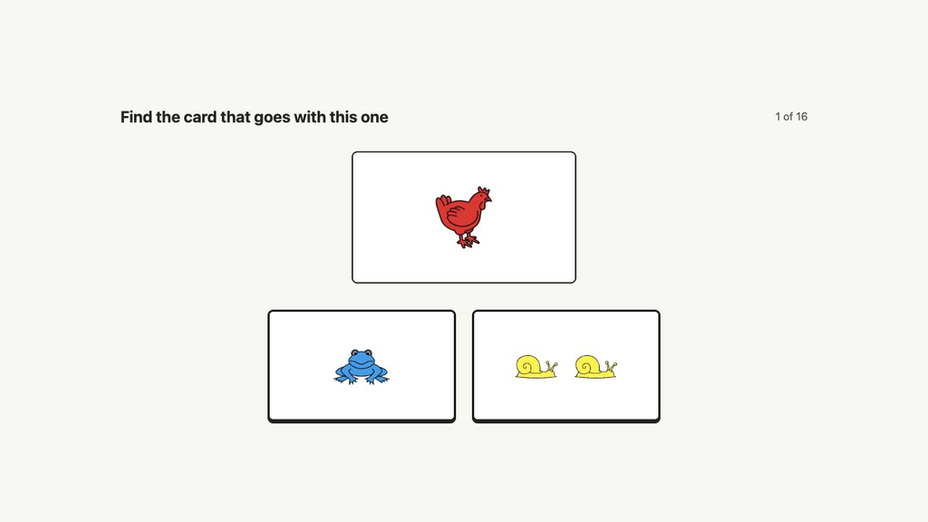

In a Phase 2 trial, the participant sees three cards and chooses the special card that matches the other two cards in different ways.

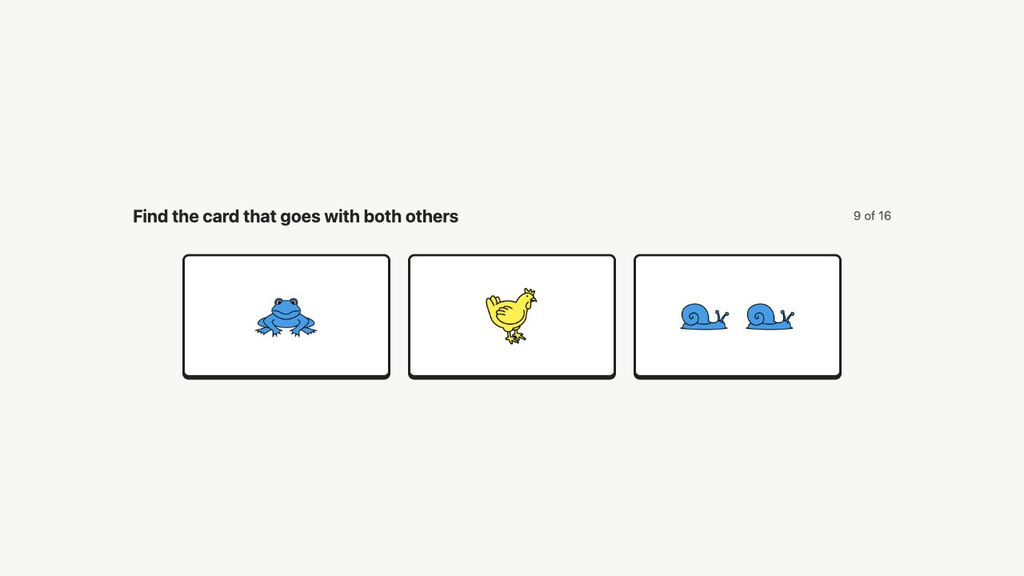

After the participant finishes the task, the final results screen shows the score summary and provides the CSV download button.

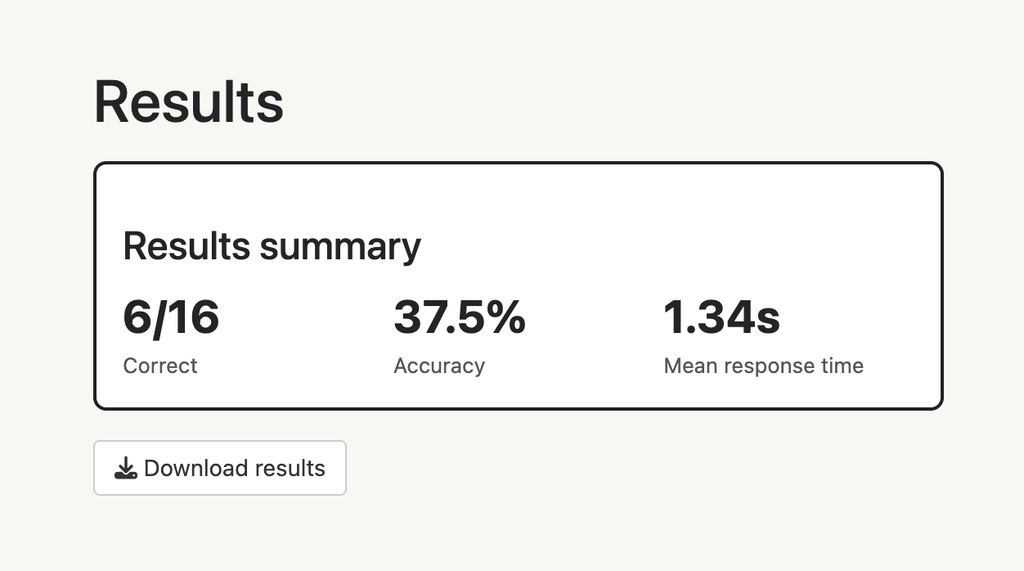

## Data output

The Shiny app stores one row per response. The downloaded CSV includes:

- `participant_id`: anonymous ID entered by the researcher
- `phase`: task phase
- `trial_id`: generated trial identifier
- `trial_number`: order of the trial in the session
- `cards_shown`: card IDs presented on that trial
- `correct_choice`: correct button position
- `chosen_choice`: participant’s selected button position
- `accuracy`: whether the response was correct
- `reaction_time`: time in seconds from trial display to response
- `timestamp`: response time

These columns allow researchers to summarize accuracy and response time by participant, phase, or trial.

## Testing and continuous integration

The package uses `testthat` unit tests for the card logic, trial generators, image assets, app helper functions, and Shiny click-through behavior. These tests check that the card deck is complete, image files exist, scoring helpers return the expected answers, generated trials follow the formal task rules, and the app can move through the main participant flow in a browser.

The Shiny click-through test also checks the final app sequence: after the last trial, the participant first sees a thank-you screen, then clicks Next to view the results summary and download the CSV file.

The repository also includes an automatic check on GitHub. When changes are uploaded, GitHub tests whether the package still installs and runs correctly.

If working from the main project folder, the tests can be run with:

```r
devtools::test("fistcards")
```

If working from inside the package folder itself, the same tests can be run with:

```r
devtools::test()
```

## Conclusion

The final version of `fistcards` provides an online version of the FIST card task as an installable R package. It contains rule-based trial generation, scoring logic, a child-facing Shiny interface, packaged image stimuli, and downloadable response data.